# Analysis 3: Statistical Programming with Daily Delhi Climate Data

Dylan Francisco

July 19, 2023

# Instructions

**Overview:** For each question, show your R code that you used to answer each question in the provided chunks. When a written response is required, be sure to answer the entire question in complete sentences outside the code chunks. When figures are required, be sure to follow all requirements to receive full credit. Point values are assigned for every part of this analysis.

**Helpful:** Make sure you knit the document as you go through the assignment. Check all your results in the created HTML file.

**Submission:** Submit via an electronic document on Canvas. Must be submitted as an HTML file generated in RStudio.

# Introduction

For this assignment, we will be using daily climate time series data in the city of Delhi between 2013 and 2017. This data was found on [Kaggle](https://www.kaggle.com/sumanthvrao/daily-climate-time-series-data) and was collected from Weather Underground API.

Below is a preview of the 2 datasets. The tibble named `DELHI.TRAIN` contains daily temperature, humidity, wind speed, and pressure measurements from 2013 and 2016. The tibble named `DELHI.TEST` contains the same information for 2017. The purpose of the test set is to evaluate our conclusions from analyses done on the train set.

```r
DELHI.TRAIN=as.tibble(read.csv("DailyDelhiClimateTrain.csv"))[-1462,]    #DO NOT CHANGE
DELHI.TEST=as.tibble(read.csv("DailyDelhiClimateTest.csv"))              #DO NOT CHANGE
head(DELHI.TRAIN)                                                        #DO NOT CHANGE
```

```
## # A tibble: 6 × 5
##   date       meantemp humidity wind_speed meanpressure
##   <chr>         <dbl>    <dbl>      <dbl>        <dbl>
## 1 2013-01-01    10        84.5       0           1016.
## 2 2013-01-02     7.4      92         2.98        1018.
## 3 2013-01-03     7.17     87         4.63        1019.
## 4 2013-01-04     8.67     71.3       1.23        1017.
## 5 2013-01-05     6        86.8       3.7         1016.
## 6 2013-01-06     7        82.8       1.48        1018
```

```r
head(DELHI.TEST)                                                         #DO NOT CHANGE
```

```
## # A tibble: 6 × 5
##   date       meantemp humidity wind_speed meanpressure
##   <chr>         <dbl>    <dbl>      <dbl>        <dbl>
## 1 2017-01-01     15.9     85.9       2.74          59
## 2 2017-01-02     18.5     77.2       2.89        1018.
## 3 2017-01-03     17.1     81.9       4.02        1018.
## 4 2017-01-04     18.7     70.0       4.54        1016.
## 5 2017-01-05     18.4     74.9       3.3         1014.
## 6 2017-01-06     19.3     79.3       8.68        1012.
```

Follow the steps to accomplish specific tasks, and do not modify code on lines with the comment `#DO NOT CHANGE`. Add code in R code chunks wherever you see `COMPLETE`. Follow instructions in each problem. If I ask you to create a loop, then you must create a loop. If I ask you to use if-else, you must use if-else.

# Assignment

## Part 1: Cleaning Data

We want to start by cleaning the two datasets.

### Q1 *(4 Points)*

Observe how the following code applied to DELHI.TRAIN splits the `date` variable into three new variables, changes those variables to numeric, and then renames all of the variables.

```r
OUT = DELHI.TRAIN %>%                                              #DO NOT CHANGE
  separate(date,into=c("Year","Month","Day"),sep="-") %>%          #DO NOT CHANGE
  mutate_at(1:3,as.numeric) %>%                                    #DO NOT CHANGE
  rename("Temperature"="meantemp","Humidity"="humidity",           #DO NOT CHANGE
         "Wind Speed"="wind_speed","Pressure"="meanpressure")      #DO NOT CHANGE

head(OUT) #DO NOT CHANGE
```

```
## # A tibble: 6 × 7
##    Year Month   Day Temperature Humidity `Wind Speed` Pressure
##   <dbl> <dbl> <dbl>       <dbl>    <dbl>        <dbl>    <dbl>
## 1  2013     1     1       10        84.5         0       1016.
## 2  2013     1     2        7.4      92           2.98    1018.
## 3  2013     1     3        7.17     87           4.63    1019.
## 4  2013     1     4        8.67     71.3         1.23    1017.
## 5  2013     1     5        6        86.8         3.7     1016.
## 6  2013     1     6        7        82.8         1.48    1018
```

Create a function named `clean.func()` that takes one argument called “data” and then does everything from the code above. We want to generalize the code above so we can run the function on both datasets `DELHI.TRAIN` and `DELHI.TEST`. We want to use this function to modify both original datasets `DELHI.TRAIN` and `DELHI.TEST` to `TRAIN.CLEAN` and `TEST.CLEAN`, respectively. We can do this since both of the original datasets are organized the same way and have the same variable names.

Code and Output:

```r
clean.func = function(data){

  returnSet <- data %>%
    separate(date, into = c("Year", "Month", "Day"), sep = "-") %>%
    mutate(across(1:3, as.numeric)) %>%
    rename("Temperature" = meantemp, "Humidity" = humidity,
           "Wind Speed" = wind_speed, "Pressure" = meanpressure)

  return(returnSet)
}

TRAIN.CLEAN=clean.func(DELHI.TRAIN) #DO NOT CHANGE
TEST.CLEAN=clean.func(DELHI.TEST) #DO NOT CHANGE
head(TRAIN.CLEAN) #DO NOT CHANGE
```

```
## # A tibble: 6 × 7
##    Year Month   Day Temperature Humidity `Wind Speed` Pressure
##   <dbl> <dbl> <dbl>       <dbl>    <dbl>        <dbl>    <dbl>
## 1  2013     1     1       10        84.5         0       1016.
## 2  2013     1     2        7.4      92           2.98    1018.
## 3  2013     1     3        7.17     87           4.63    1019.
## 4  2013     1     4        8.67     71.3         1.23    1017.
## 5  2013     1     5        6        86.8         3.7     1016.
## 6  2013     1     6        7        82.8         1.48    1018
```

```r
head(TEST.CLEAN) #DO NOT CHANGE
```

```
## # A tibble: 6 × 7
##    Year Month   Day Temperature Humidity `Wind Speed` Pressure
##   <dbl> <dbl> <dbl>       <dbl>    <dbl>        <dbl>    <dbl>
## 1  2017     1     1        15.9     85.9         2.74      59
## 2  2017     1     2        18.5     77.2         2.89    1018.
## 3  2017     1     3        17.1     81.9         4.02    1018.
## 4  2017     1     4        18.7     70.0         4.54    1016.
## 5  2017     1     5        18.4     74.9         3.3     1014.
## 6  2017     1     6        19.3     79.3         8.68    1012.
```

### Q2 *(4 Points)*

In the following code, I create a numeric vector called `month` that contains values 1 for January and 2 for February. Observe how the following code rewrites over the original numeric vector `month` to a categorical vector with the names of months rather than the original numbers.

```r
month=c(1,2,2,1,2,2,1,2,1,2)  #DO NOT CHANGE

if(month[1]==1){          #DO NOT CHANGE
  month[1]="January"          #DO NOT CHANGE
} else if(month[1]==2){       #DO NOT CHANGE
  month[1]="February"         #DO NOT CHANGE
}                         #DO NOT CHANGE

if(month[2]==1){          #DO NOT CHANGE
  month[2]="January"          #DO NOT CHANGE
} else if(month[2]==2){       #DO NOT CHANGE
  month[2]="February"         #DO NOT CHANGE
}                         #DO NOT CHANGE

print(month)                 #DO NOT CHANGE
```

```
##  [1] "January"  "February" "2"        "1"        "2"        "2"
##  [7] "1"        "2"        "1"        "2"
```

Create a function called `month.func` that has one argument `month` (this would ideally be a numeric vector with discrete values 1 through 12) and rewrites over the initial vector `month` to contain month names from “January” to “December” rather than numbers.

After creating two new datasets identical to the previous datasets, we rewrite over the original variables named `Month` using our new function applied to the old variable. The “dollar sign” can be used to access variables from datasets and even create new variables from datasets.

Code and Output:

```r
month.func <- function(month) {
  month_names <- c("January", "February", "March", "April", "May", "June",
                   "July", "August", "September", "October", "November", "December")

  month = month_names[month]

  return(month)
}

TRAIN.CLEAN.2=TRAIN.CLEAN #DO NOT CHANGE
TEST.CLEAN.2=TEST.CLEAN #DO NOT CHANGE
TRAIN.CLEAN.2$Month=month.func(TRAIN.CLEAN$Month) #DO NOT CHANGE
TEST.CLEAN.2$Month=month.func(TEST.CLEAN$Month) #DO NOT CHANGE
unique(TRAIN.CLEAN.2$Month) #DO NOT CHANGE
```

```
##  [1] "January"   "February"  "March"     "April"     "May"       "June"
##  [7] "July"      "August"    "September" "October"   "November"  "December"
```

```r
unique(TEST.CLEAN.2$Month) #DO NOT CHANGE
```

```
## [1] "January"  "February" "March"    "April"
```

### Q3 *(4 Points)*

Currently, the data is sorted by date starting with January 1, 2013. Our goal is to change all of the numeric values for day to “Tuesday”, “Wednesday”, Thursday”, etc. Run the following code line-by-line and observe how the `rep()`function works.

```r
rep(c("Bill","Ted"),times=5)        #DO NOT CHANGE
```

```
##  [1] "Bill" "Ted"  "Bill" "Ted"  "Bill" "Ted"  "Bill" "Ted"  "Bill" "Ted"
```

```r
rep(c("Bill","Ted"),each=2,times=4) #DO NOT CHANGE
```

```
##  [1] "Bill" "Bill" "Ted"  "Ted"  "Bill" "Bill" "Ted"  "Ted"  "Bill" "Bill"
## [11] "Ted"  "Ted"  "Bill" "Bill" "Ted"  "Ted"
```

```r
rep(c("Bill","Ted"),length.out=11)  #DO NOT CHANGE
```

```
##  [1] "Bill" "Ted"  "Bill" "Ted"  "Bill" "Ted"  "Bill" "Ted"  "Bill" "Ted"
## [11] "Bill"
```

```r
rep(c("Bill","Ted"),length.out=12)  #DO NOT CHANGE
```

```
##  [1] "Bill" "Ted"  "Bill" "Ted"  "Bill" "Ted"  "Bill" "Ted"  "Bill" "Ted"
## [11] "Bill" "Ted"
```

Now, you must use the `rep()` function to overwrite the `Day` variable replacing the day of the month with the name of the day. For this, it is important to know that the first day in the training set is a Tuesday. Assume there are no days missing data between the first observation in the training set and the last observation of the testing set. Also, notice how the last observation in the training set is December 31, 2016, and the first observation in the testing set is January 1, 2017. If you don’t use the `rep()` function you will get 0 points.

Code and Output:

```r
TRAIN.CLEAN.3=TRAIN.CLEAN.2 #DO NOT CHANGE
TEST.CLEAN.3=TEST.CLEAN.2   #DO NOT CHANGE

TRAIN.CLEAN.3$Day = rep(c("Tuesday", "Wednesday", "Thursday", "Friday",
                          "Saturday", "Sunday", "Monday"),
                        length.out = nrow(TRAIN.CLEAN.3))
TEST.CLEAN.3$Day  = rep(c("Sunday", "Monday", "Tuesday", "Wednesday",
                          "Thursday", "Friday", "Saturday"),
                        length.out = nrow(TEST.CLEAN.3))

unique(TRAIN.CLEAN.3$Day[c(1,1461)]) #DO NOT CHANGE
```

```
## [1] "Tuesday"  "Saturday"
```

```r
unique(TEST.CLEAN.3$Day[c(1,114)]) #DO NOT CHANGE
```

```
## [1] "Sunday" "Monday"
```

### Q4 *(4 Points)*

Since this is America, we want to drop that Celsius nonsense like it is hot. I want you to create a function called `cels.2.fahr()` that converts a temperature (or vector of temperatures) measured in Celsius to the equivalent temperature(s) in Fahrenheit. Google the formula necessary for this conversion. I am not going to help you with these childish things.

Code and Output:

```r
cels.2.fahr = function(tempInCel){
  tempInFah = (tempInCel * (9/5)) +32

  return(tempInFah)

}

TRAIN.FINAL=TRAIN.CLEAN.3 #DO NOT CHANGE
TEST.FINAL=TEST.CLEAN.3   #DO NOT CHANGE
TRAIN.FINAL$Temperature=cels.2.fahr(TRAIN.CLEAN.3$Temperature) #DO NOT CHANGE
TEST.FINAL$Temperature=cels.2.fahr(TEST.CLEAN.3$Temperature) #DO NOT CHANGE
TRAIN.FINAL$Temperature[1:10] #DO NOT CHANGE
```

```
##  [1] 50.00000 45.32000 44.90000 47.60000 42.80000 44.60000 44.60000 47.94286
##  [9] 57.20000 51.80000
```

```r
TEST.FINAL$Temperature[1:10] #DO NOT CHANGE
```

```
##  [1] 60.64348 65.30000 62.80000 65.66000 65.10000 66.77273 58.47500 60.23158
##  [9] 58.22857 53.80000
```

## Part 2: Summarizing the Data from the Cleaned Train Set

Next, we move to summarizing useful information from the training dataset that we created called `TRAIN.FINAL`. All questions in this section only involve the training dataset.

### Q1 *(4 Points)*

Our goal is to create a matrix that summarizes the average temperature for each combination of month and day. We start by creating a matrix named `MEAN.TEMP.TRAIN` full of missing values. Use a double loop to fill in the matrix with the average temperature for each combination of month and day. For example, the element in row 1 and column 1 should contain the average temperature of all Mondays in Januaries across the years contained in `TRAIN.FINAL`.

Code and Output:

```r
MEAN.TEMP.TRAIN=matrix(NA,12,7) #DO NOT CHANGE
rownames(MEAN.TEMP.TRAIN)=c("January","February","March","April","May","June",         #DO NOT CHANGE
                         "July","August","September","October","November","December")  #DO NOT CHANGE
colnames(MEAN.TEMP.TRAIN)=c("Monday","Tuesday","Wednesday",                            #DO NOT CHANGE
                         "Thursday","Friday","Saturday","Sunday")                      #DO NOT CHANGE

for(j in 1:12){    #DO NOT CHANGE
  for(k in 1:7){   #DO NOT CHANGE

    month <- rownames(MEAN.TEMP.TRAIN)[j]
    day <- colnames(MEAN.TEMP.TRAIN)[k]

    average_temp <- mean(TRAIN.FINAL$Temperature[TRAIN.FINAL$Month == month & TRAIN.FINAL$Day == day])

    MEAN.TEMP.TRAIN[j, k] <- average_temp


  }                #DO NOT CHANGE
}                  #DO NOT CHANGE

print(MEAN.TEMP.TRAIN) #DO NOT CHANGE
```

```
##             Monday  Tuesday Wednesday Thursday   Friday Saturday   Sunday
## January   55.74915 55.93351  56.32036 56.05617 56.28573 55.83292 55.82763
## February  63.77733 63.55359  63.75333 64.82944 64.31418 63.20710 62.57857
## March     72.15333 73.04387  73.16611 74.27693 74.02597 73.58530 72.59840
## April     84.72431 85.10512  84.96768 84.69818 84.21613 85.47456 84.94464
## May       91.58485 91.02779  91.44571 92.51168 92.71331 91.84173 92.51113
## June      92.01714 91.49592  93.67786 92.23713 93.96467 93.37868 92.41000
## July      87.34811 88.20000  88.46417 88.75625 87.49889 87.12739 87.00960
## August    87.81435 87.11381  87.41857 86.83468 87.21698 86.50968 86.71269
## September 86.94200 87.94546  86.90454 86.22744 86.37482 86.51743 86.45329
## October   81.70367 81.49940  80.75302 80.28819 79.49971 80.79591 81.22662
## November  69.53883 69.18590  69.04703 69.02130 69.07144 69.26146 69.13883
## December  60.35455 60.87842  61.35075 60.74833 59.70109 59.21615 58.95727
```

### Q2 *(2 Points)*

Run the following code line-by-line and observe what is happening.

```r
x=c(35,27,28,40)    #DO NOT CHANGE

range=max(x)-min(x) #DO NOT CHANGE
print(range)        #DO NOT CHANGE
```

```
## [1] 13
```

Create a function called `RANGE.func` that inputs a vector and outputs the range of the observations in that vector. You should not use the `print()` function inside of `RANGE.func()`. The code below will test to see if your function works.

Code and Output:

```r
RANGE.func <- function(c) {
  range = max(c) - min(c)
  return(range)
}

try=c(1,2,3,4,5)        #DO NOT CHANGE
print(try)              #DO NOT CHANGE
```

```
## [1] 1 2 3 4 5
```

```r
print(RANGE.func(try))  #DO NOT CHANGE
```

```
## [1] 4
```

### Q3 *(2 Points)*

The `apply()` function is very helpful for applying functions to rows or columns of matrices. Google this function to see examples of how it is used.

Use `apply()` with your function `RANGE.func()` to create a vector called `RANGE.MONTH.TRAIN` that contains the range of each row in `MEAN.TEMP.TRAIN`.

Use `apply()` with your function `RANGE.func()` to create a vector called `RANGE.DAY.TRAIN` that contains the range of each column in `MEAN.TEMP.TRAIN`.

Code and Output:

```r
RANGE.MONTH.TRAIN <- apply(MEAN.TEMP.TRAIN, 1, RANGE.func)
RANGE.DAY.TRAIN <- apply(MEAN.TEMP.TRAIN, 2, RANGE.func)

print(RANGE.MONTH.TRAIN) #DO NOT CHANGE
```

```
##   January  February     March     April       May      June      July    August
## 0.5712054 2.2508644 2.1235994 1.2584244 1.6855200 2.4687408 1.7466492 1.3046673
## September   October  November  December
## 1.7180265 2.2039583 0.5175360 2.3934782
```

```r
print(RANGE.DAY.TRAIN) #DO NOT CHANGE
```

```
##    Monday   Tuesday Wednesday  Thursday    Friday  Saturday    Sunday
##  36.26799  35.56242  37.35750  36.45552  37.67893  37.54576  36.68350
```

### Q4 *(8 Points)*

Run the following code line-by-line and observe what is happening.

```r
x=NULL   #DO NOT CHANGE
x=c(x,3) #DO NOT CHANGE
x=c(x,4) #DO NOT CHANGE
x=c(x,5) #DO NOT CHANGE
print(x) #DO NOT CHANGE
```

```
## [1] 3 4 5
```

Below, I created two empty objects named `WEEKDAY.HUMIDITY` and `WEEKEND.HUMIDITY`. I want you to loop through each row in `TRAIN.FINAL` moving through the data in chronological order. If the row involves a weekend, I want you to add the humidity of that day to `WEEKEND.HUMIDITY`, otherwise, I want you to add the humidity of that day to `WEEKDAY.HUMIDITY`. For our purposes, only Saturday and Sunday are considered weekends. Also, your code needs to utilize a loop and an if-else control structure or you will get 0 points. At the end, `WEEKDAY.HUMIDITY` and `WEEKEND.HUMIDITY` should be vectors.

The last line of code performs a basic t-test . In the space provided below, I want you to explain what this t-test function is being used to test and summarise what we learn about humidity from this t-test. Write in complete sentences using words as if you were explaining this to someone who knows very little about statistics. Explain what you learned about humidity, do not just explain what a t-test is. They don’t care about that nonsense, because they have a life.

Code and Output (4 Points):

```r
WEEKDAY.HUMIDITY=NULL #DO NOT CHANGE
WEEKEND.HUMIDITY=NULL #DO NOT CHANGE

weekend = c("Saturday", "Sunday")

for(j in 1:1461){   #DO NOT CHANGE

  if (TRAIN.FINAL$Day[j] %in% weekend) {
    WEEKEND.HUMIDITY <- append(WEEKEND.HUMIDITY, TRAIN.FINAL$Humidity[j])
  } else {
    WEEKDAY.HUMIDITY <- append(WEEKDAY.HUMIDITY, TRAIN.FINAL$Humidity[j])
  }

}                   #DO NOT CHANGE


t.test(x=WEEKDAY.HUMIDITY,y=WEEKEND.HUMIDITY) #DO NOT CHANGE
```

```
##
##  Welch Two Sample t-test
##
## data:  WEEKDAY.HUMIDITY and WEEKEND.HUMIDITY
## t = -1.6086, df = 733.13, p-value = 0.1081
## alternative hypothesis: true difference in means is not equal to 0
## 95 percent confidence interval:
##  -3.5369866  0.3511997
## sample estimates:
## mean of x mean of y
##  60.29021  61.88310
```

Answer (4 Points): The t-test that we used measured the difference in means of humidity on Weekends and Weekdays and showed that there is not enough significant evidence to conclude that the average humidity differs greatly between Weekends and Weekdays. Since we are 95% sure that the true difference in means of humidity between the types of days includes the number 0, we can say that there is not much a difference in the average humidity between Weekends and Weekdays.

## Part 3: Creating Two New Variables Helpful for Time Series Data

When you have data that is organized chronologically, there are some cool features of the data we can explore using lags, differences, moving averages, moving ranges, etc. In this section, we will only create these variables in the training dataset named `TRAIN.FINAL`. Typically, we would also want to create these same variables in the testing dataset named `TEST.FINAL`.

### Q1 *(4 Points)*

We can create a new variable called `Pressure Percent Change` in TRAIN.FINAL that currently contains all missing values. If we wanted to change the 4th observation of `Pressure Percent Change` to 32, we could use the code `TRAIN.FINAL$`Pressure Percent Change`[4]=32`. Each value of `Pressure Percent Change` can be calculated from the following formula:

$\textrm{Pressure Percent Change}=\frac{\textrm{Pressure Today}-\textrm{Pressure Yesterday}}{\textrm{Pressure Yesterday}}$

Use a loop to replace each missing value in the new variable called `Pressure Percent Change` with the actual value according to the formula. If you don’t use a loop, you will get 0 points.

Code and Output (4 Points):

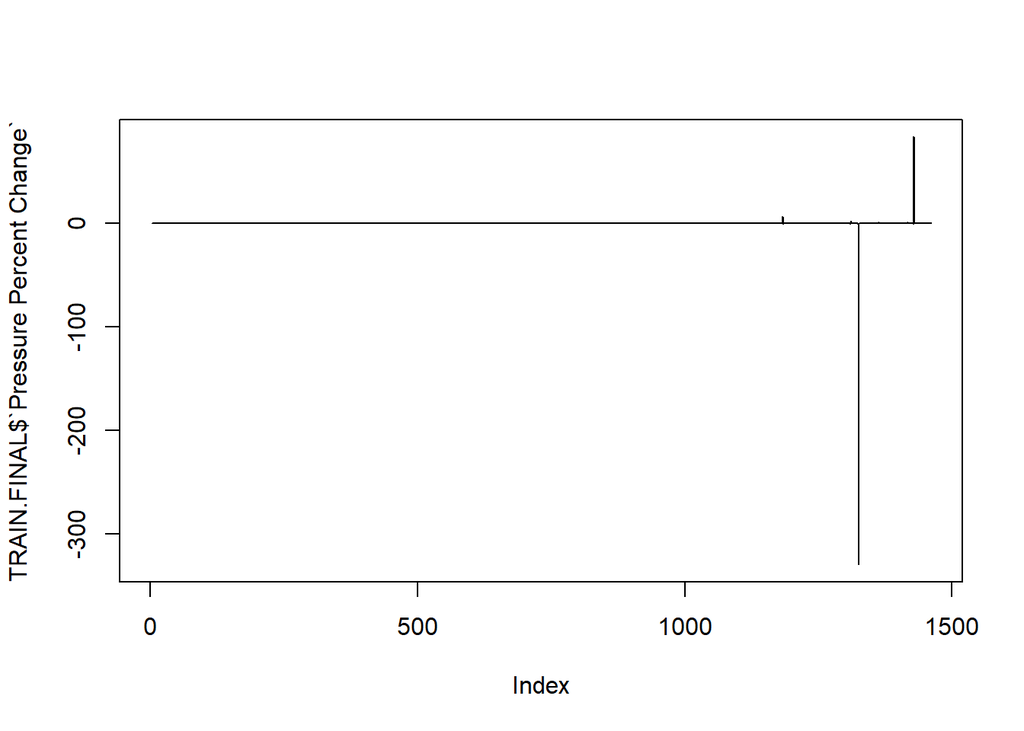

```r
TRAIN.FINAL$`Pressure Percent Change`=NA #DO NOT CHANGE


for (i in 2:nrow(TRAIN.FINAL)) {
  pressure_today <- TRAIN.FINAL$Pressure[i]
  pressure_yesterday <- lag(TRAIN.FINAL$Pressure)[i]

  percent_change <- (pressure_today - pressure_yesterday) / pressure_yesterday

  TRAIN.FINAL$`Pressure Percent Change`[i] <- percent_change
}

plot(TRAIN.FINAL$`Pressure Percent Change`,type="l") #DO NOT CHANGE
```

### Q2 *(4 Points)*

We create a new variable called `Pressure 3-Day Average` in TRAIN.FINAL that starts with all missing values. If we wanted to change the 3rd observation of `Pressure 3-Day Average` to 50, we could use the code `TRAIN.FINAL$`Pressure 3-Day Average`[3]=50`. Each value of `Pressure 3-Day Average` can be calculated from the following formula:

$\textrm{Pressure 3-Day Average}=\frac{\textrm{Pressure Yesterday}+\textrm{Pressure Today}+\textrm{Pressure Tomorrow}}{3}$

Use a loop to replace each missing value in the new variable called `Pressure 3-Day Average` with the actual value according to the formula. If you don’t use a loop, you will get 0 points.

Code and Output (4 Points):

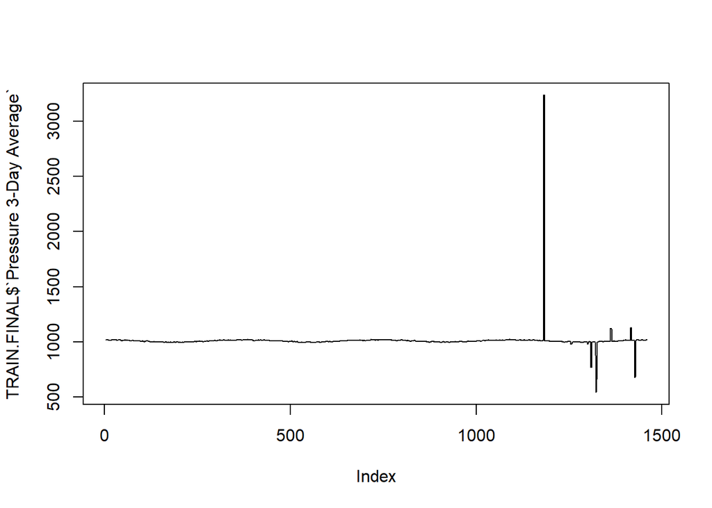

```r
TRAIN.FINAL$`Pressure 3-Day Average`=NA #DO NOT CHANGE

for (i in 2:(nrow(TRAIN.FINAL) - 1)) {
  pressure_today <- TRAIN.FINAL$Pressure[i]
  pressure_yesterday <- lag(TRAIN.FINAL$Pressure)[i]
  pressure_tomorrow <- lead(TRAIN.FINAL$Pressure)[i]

  average_pressure <- (pressure_yesterday + pressure_today + pressure_tomorrow) / 3

  TRAIN.FINAL$`Pressure 3-Day Average`[i] <- average_pressure
}

plot(TRAIN.FINAL$`Pressure 3-Day Average`,type="l") #DO NOT CHANGE
```